# fifaJup

#### Random Forests

Next we compare random forest performance as we alter bagging vs boosting, max_features, and number of estimators

Fitting a random forest model with bagging and max_features = 6

```
Max test score: 0.7451043338683788
experiment runtime: 190.03438806533813
```

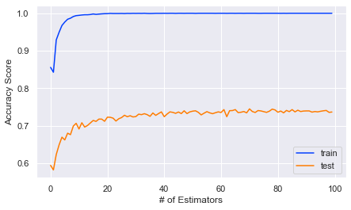

```python
start = time.time()
rf_helper(bag=True, max_features=6) # helper function to rest multiple number of trees in the forest at once
print('experiment runtime: {}'.format(time.time()-start))
```

Fitting a random forest model with boosting and max_features = 6

```
Max test score: 0.29373996789727125
experiment runtime: 155.00030517578125
```

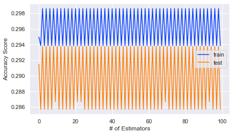

```python
start = time.time()
rf_helper(bag=False, max_features=6) # using boosting rather than bagging
print('experiment runtime: {}'.format(time.time()-start))
```

Fitting a random forest model with bagging and max_features = 5

```
Max test score: 0.74446227929374
experiment runtime: 170.90978455543518
```

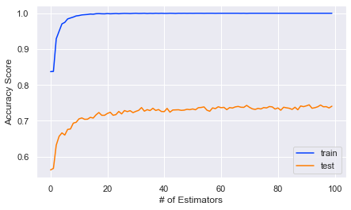

```python
start = time.time()
rf_helper(bag=True, max_features=5)
print('experiment runtime: {}'.format(time.time()-start))
```

Fitting a random forest model with bagging using max_features = 17

```
Max test score: 0.7441412520064206
experiment runtime: 434.8330216407776
```

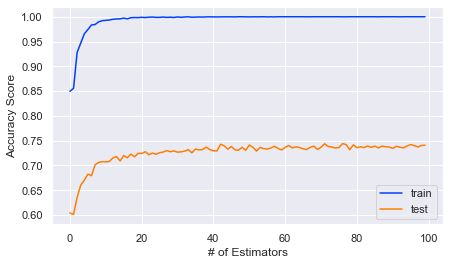

```python
start = time.time()
rf_helper(bag=True, max_features=17)
print('experiment runtime: {}'.format(time.time()-start))
```

#### Optimal Random Forest Model

The final hyperparameters are:

*bagging vs boosting:* Bagging

*n_estimators:* 43

*max_features:* 17

```
0 %	...	25 %	...	50 %	...	75 %	...
Total experiment runtime: 744.4076113700867s
```

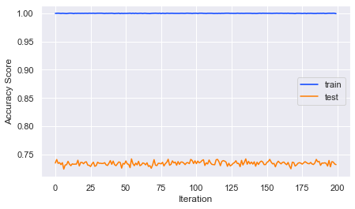

```python
expSt = time.time()
train=[]
test=[]
time2=[]
for i in range(200):
    if i % 50 == 0:
        print(int(i/2),'%\t...\t',end='')
    start = time.time()
    rf = RandomForest(X,b,random=True) # intializing the RF class with a random split of train data
    rf.create_fit(bag=True, max_features=17, n_estimators=43) # fitting the model to the train data
    train.append(rf.calc_performance(rf.trainX,rf.trainb))
    test.append(rf.calc_performance(Xho,bho)) # testing model performance on holdout data
    time2.append(time.time()-start)
results2 = pd.DataFrame.from_dict({'train':train,'test':test}) # create a df from train and test performance
sns.lineplot(data=results2, dashes=False).set_xlabel('Iteration') # plot the df
plt.ylabel('Accuracy Score')
print('\nTotal experiment runtime: {}s'.format(time.time()-expSt))
```

```python
mean = np.mean(test)
ci = st.t.interval(0.95, len(test)-1, loc=np.mean(test), scale=st.sem(test))
print('avg test accuracy: {}'.format(mean))
print('95% confidence interval on average accuracy: \n\t[{},{}]'.format(ci[0],ci[1]))
print('avg runtime (per iteration): {}s'.format(np.array(time2).mean()))
```

```
avg test accuracy: 0.7344826844482685
95% confidence interval on average accuracy:
	[0.734000877384033,0.734964491512504]
avg runtime (per iteration): 3.720984146595001s
```

We see that the random forest performs extremely well on the training data but does a worse job at generalizing to test data than the optimal SVM model.

#### Neural Networks

Finally, we test different neural networks to choose an optimal neural network model

Neural network with 2 hidden layers, 150 perceptrons each, activation_function=relu, lr=0.75, epochs=500

```
Net(
  (hidden1): Linear(in_features=35, out_features=150, bias=True)
  (hidden2): Linear(in_features=150, out_features=150, bias=True)
  (out): Linear(in_features=150, out_features=20, bias=True)
)
Max test score: 0.777207062600321
experiment runtime: 59.41456890106201
```

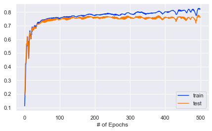

```python
start = time.time()
net = Net(X, b, n_hidden=[150,150], n_output=20, activ_func='relu') # creating the net
print(net)
optimizer = torch.optim.SGD(net.parameters(), lr=0.75) # choosing the optimizing function (Stochastic Gradient Descent)
loss_func = torch.nn.CrossEntropyLoss() # choosing the loss function
results, runtime, out = net.train_net(num_epochs=500, print_iters=False) # helper function to train the neural network
print('Max test score: {}'.format(results['test'].max()))
sns.lineplot(data=results, dashes=False).set_xlabel('# of Epochs') # plotting performance
print('experiment runtime: {}'.format(time.time()-start))
```

Neural network with 4 hidden layers, 75 perceptrons each, activation_function=relu, lr=0.3, epochs=2000

```
Net(
  (hidden1): Linear(in_features=35, out_features=75, bias=True)
  (hidden2): Linear(in_features=75, out_features=75, bias=True)
  (hidden3): Linear(in_features=75, out_features=75, bias=True)
  (hidden4): Linear(in_features=75, out_features=75, bias=True)
  (out): Linear(in_features=75, out_features=20, bias=True)
)
Max test score: 0.7765650080256822
experiment runtime: 224.4491879940033
```

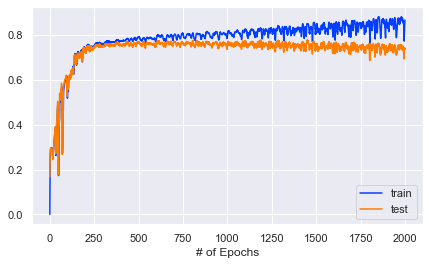

```python
start = time.time()
net = Net(X, b, n_hidden=[75,75,75,75], n_output=20, activ_func='relu')
print(net)
optimizer = torch.optim.SGD(net.parameters(), lr=0.3)
loss_func = torch.nn.CrossEntropyLoss()
results, runtime, out = net.train_net(num_epochs=2000, print_iters=False)
print('Max test score: {}'.format(results['test'].max()))
sns.lineplot(data=results, dashes=False).set_xlabel('# of Epochs')
print('experiment runtime: {}'.format(time.time()-start))
```

Neural network with 3 hidden layers, 35,55,27 perceptrons respectively, activation_function=sigmoid, lr=0.7, epochs=2000

```
Net(
  (hidden1): Linear(in_features=35, out_features=35, bias=True)
  (hidden2): Linear(in_features=35, out_features=55, bias=True)
  (hidden3): Linear(in_features=55, out_features=27, bias=True)
  (out): Linear(in_features=27, out_features=20, bias=True)
)

max test score: 0.762760834670947
experiment runtime: 86.77672672271729
```

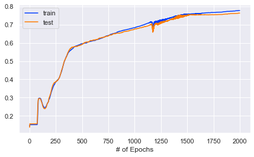

```python
start = time.time()
net = Net(X, b, n_hidden=[35,55,27], n_output=20, activ_func='sigmoid')
print(net)
optimizer = torch.optim.SGD(net.parameters(), lr=0.7)
loss_func = torch.nn.CrossEntropyLoss()
results, runtime, out = net.train_net(num_epochs=2000, print_iters=False)
print('\nmax test score: {}'.format(results['test'].max()))
sns.lineplot(data=results, dashes=False).set_xlabel('# of Epochs')
print('experiment runtime: {}'.format(time.time()-start))
```

Neural network with 3 hidden layers, 300 perceptrons each, activation_function=relu, lr=0.75, epochs=500

```
Net(
  (hidden1): Linear(in_features=35, out_features=300, bias=True)
  (hidden2): Linear(in_features=300, out_features=300, bias=True)
  (hidden3): Linear(in_features=300, out_features=300, bias=True)
  (out): Linear(in_features=300, out_features=20, bias=True)
)

max test score: 0.7752808988764045
experiment runtime: 186.07071042060852
```

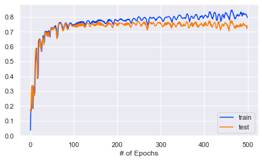

```python
start = time.time()
net = Net(X, b, n_hidden=[300,300,300], n_output=20, activ_func='relu')
print(net)
optimizer = torch.optim.SGD(net.parameters(), lr=0.75)
loss_func = torch.nn.CrossEntropyLoss()
results, runtime, out = net.train_net(num_epochs=500, print_iters=False)
print('\nmax test score: {}'.format(results['test'].max()))
sns.lineplot(data=results, dashes=False).set_xlabel('# of Epochs')
print('experiment runtime: {}'.format(time.time()-start))
```

```
Net(
  (hidden1): Linear(in_features=35, out_features=50, bias=True)
  (hidden2): Linear(in_features=50, out_features=50, bias=True)
  (out): Linear(in_features=50, out_features=20, bias=True)
)

max test score: 0.7717495987158909
experiment runtime: 45.39843201637268
```

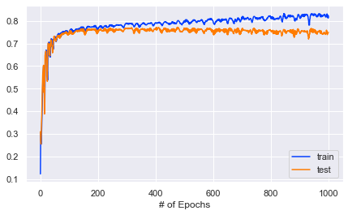

```python
start = time.time()
net = Net(X, b, n_hidden=[50,50], n_output=20, activ_func='relu')
print(net)
optimizer = torch.optim.SGD(net.parameters(), lr=0.8)
loss_func = torch.nn.CrossEntropyLoss()
results, runtime, out = net.train_net(num_epochs=1000, print_iters=False)
print('\nmax test score: {}'.format(results['test'].max()))
sns.lineplot(data=results, dashes=False).set_xlabel('# of Epochs')
print('experiment runtime: {}'.format(time.time()-start))
```

#### Optimal Neural Network Model

The final hyperparameters are:

*# of hidden layers:* 2

*# of nodes in each hidden layer:* 50

*activation function:* 'relu'

*learning rate:* 0.8

*number of epochs:* 200

```
0 %	...	25 %	...	50 %	...	75 %	...
Total experiment runtime: 1703.612209558487s
```

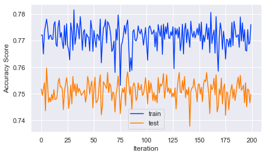

```python
expSt = time.time()
train=[]
test=[]
time3=[]
for i in range(200):
    if i % 50 == 0:
        print(int(i/2),'%\t...\t',end='')
    start = time.time()
    net = Net(X, b, n_hidden=[50,50], n_output=20, activ_func='relu')
    optimizer = torch.optim.SGD(net.parameters(), lr=0.8)
    loss_func = torch.nn.CrossEntropyLoss()
    results, runtime, out = net.train_net(num_epochs=200)
    train.append(results['train'][len(results['train'])-1])
    test.append(net.test_net(test_final=True)) # testing the neural net on the holdout data
    time3.append(time.time()-start)
results3 = pd.DataFrame.from_dict({'train':train,'test':test}) # creating the df of model performance
sns.lineplot(data=results3, dashes=False).set_xlabel('Iteration') # creating the plot from df
plt.ylabel('Accuracy Score')
print('\nTotal experiment runtime: {}s'.format(time.time()-expSt))
```

```python
mean = np.mean(test)
ci = st.t.interval(0.95, len(test)-1, loc=np.mean(test), scale=st.sem(test))
print('avg test accuracy: {}'.format(mean))
print('95% confidence interval on average accuracy: \n\t[{},{}]'.format(ci[0],ci[1]))
print('avg runtime (per iteration): {}s'.format(np.array(time3).mean()))
```

```
avg test accuracy: 0.7510755001075501
95% confidence interval on average accuracy:
	[0.7505563268966702,0.75159467331843]
avg runtime (per iteration): 8.51698388338089s
```

The neural network generalizes well to the testing data and we see a small drop in performance between the train and test. The neural network also has a relatively long training time compared to the other two models.

## Comparing Algorithm Performance

To compare each algorithms respective performance, 200 iterations of training with random train splits and testing on held out data (that was not seen during hyper parameter tuning) was performed for each algorithm. The performance of each algorithm was recorded and plotted below.

Comparing model performance on the held out validation set

```
Validation Accuracy vs. Iteration
```

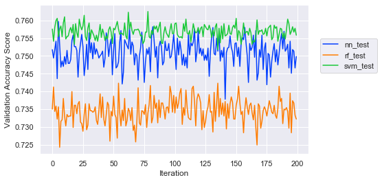

```python
fig = plt.figure()
ax = plt.subplot(111)
results={}
results['nn_test'] = results3['test']
results['rf_test'] = results2['test']
results['svm_test'] = results1['test']
results = pd.DataFrame.from_dict(results)
sns.lineplot(data=results, dashes=False).set_xlabel('Iteration')
ax.legend(loc='upper center', bbox_to_anchor=(1.15, 0.8), shadow=False, ncol=1)
plt.ylabel('Validation Accuracy Score')
print('Validation Accuracy vs. Iteration')
```

From the plot above we can see that the SVM model consistently outperformed the other 2 algorithms (the neural network model outperformed the SVM model on a few occasions). We also note that SVM model was the most consistent in validation accuracy (had the least variance) of all the models.

From the SVM optimal model, I am 95% confident that the SVM model will average correctly classifying between 75.6% and 75.7% of points in any batch shown to it.

For the neural network model, I am 95% confident that the average validation score is between 75.06% and 75.16% for any future batches presented to the model.

Comparing runtimes for each algorithm:

```
Runtime vs. Iteration
```

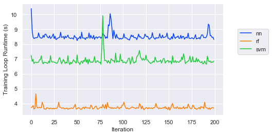

```python
fig = plt.figure()
ax = plt.subplot(111)
results={}
results['nn'] = time3
results['rf'] = time2
results['svm'] = time1
results = pd.DataFrame.from_dict(results)
sns.lineplot(data=results, dashes=False).set_xlabel('Iteration')
ax.legend(loc='upper center', bbox_to_anchor=(1.15, 0.8), shadow=False, ncol=1)
plt.ylabel('Training Loop Runtime (s)')
print('Runtime vs. Iteration')
```

## Conclusion

In conclusion, when choosing an algorithm to use for data from this domain, there are 3 important factors.

- Validation Accuracy
- Train Time
- Complexity

Using the validation accuracy and runtime plots provided above alongside the hyperparemeter tuning, we can easily rank the three algorithms in each category

1. **Support Vector Machines:**
   - Validation Acuracy: Best
   - Train Time: Moderate
   - Complexity: Moderate Complexity (3 hyperparameters, tuned to be high complexity)
2. **Random Forests:**
   - Validation Accuracy: Worst
   - Train Time: Best
   - Complexity: Least Complex (3 hyperparameters, tuned to be low complexity)
3. **Neural Networks:**
   - Validation Accuracy: Moderate
   - Train Time: Worst
   - Complexity: Most Complex (5 hyperparameters)

Thus, the algorithm I would utilize on real world data from the same domain would be Support Vector Machines with the 'rbf' kernel, C = 1.0, and gamma = 0.01 . This algorithm outperformed both random forests and neural networks in validation accuracy and took less time to train than neural networks (but more than random forests). Despite *C* and *gamma* being more complex in the model, the difference between train and test accuracy is very small ( less than 0.02 ), so the increased complexity still generalizes well and does not take too long to run. I am also 95% confident that the SVM model will average between 75.6% and 75.7% classification accuracy when classifying new batches of players (unseen to the model).

If a new dataset from the same domain needed to be tested that was significantly larger than the current dataset, I would choose random forests as my algorithm. The fast training time and small complexity would generalize well to a large dataset quickly and provide decent validation accuracy.

The neural network model is very complex and offers no benefit to validation accuracy or training runtime, thus, I would not use neural networks in the real world on data from this domain.

## Acknowledgements

1. [PyTorch docs](https://pytorch.org/docs/stable/index.html)
2. [FIFA 19 Dataset on Kaggle](https://www.kaggle.com/karangadiya/fifa19)
3. [SciKit-Learn docs](https://scikit-learn.org/stable/index.html)
4. [Seaborn docs](https://seaborn.pydata.org/index.html)
5. [Additional Research on SVMs](https://medium.com/machine-learning-101/chapter-2-svm-support-vector-machine-theory-f0812effc72)
6. [Additional Research on Random Forests](https://builtin.com/data-science/random-forest-algorithm#hyperparameters)
7. [Additional Research on Neural Networks](http://news.mit.edu/2017/explained-neural-networks-deep-learning-0414)

## Future Research

For those interested, there are still several interesting questions that can be raised from this analysis

Which positions are misclassified most often?

Is there a correlation between any one feature and misclassification (i.e. do higher 'Overall' players have more customized feature sets that lead to increased misclassification?)

Would breaking positions into larger buckets improve performance (i.e attacker, midfield, defensive)

## Back to Top

```python
print('Notebook Total Runtime: {}'.format(time.time() - bookStart))
```

```
Notebook Total Runtime: 6017.4951910972595
```